# Nutrients and species presence in estuaries

The goal of this notebook is to test whether nutrient concentrations change the presence of fish species in estuaries, on top of the continuum baseline of D19: the POMET presence model with log salinity and its square, distance to the mouth, depth, temperature, gear and month, year and a spatial field.

Steps: (1) nutrient concentrations at the fishing operations; (2) their relation with the baseline variables, to see what nutrient variation is left for a presence model; (3) presence models with nutrients (next).

## Setup

```r
library(renv)
renv::load()
```

```
- The project is out-of-sync -- use `renv::status()` for details.
```

```r
library(targets)
library(here)
tar_config_set(
  store = here::here("_targets")
)
library(ggplot2)
library(dplyr)
devtools::load_all()
nice_theme()
```

```r
visit <- tar_read(pomet_presence_visit)
nutrient_label <- c(NH4 = "Ammonium (NH4)", `NO3+NO2` = "Nitrate + nitrite (NO3+NO2)", PO4 = "Phosphate (PO4)")
nutrient <- tar_read(pomet_nutrient) |>
  mutate(nutrient = factor(nutrient_label[parameter_code], nutrient_label), log_pred = log(pred)) |>
  inner_join(select(visit, operation_id, zone_id, year, month, salinity, log_salinity, distance, depth_pomet, temperature), by = "operation_id")
coast <- coastline()
```

## Nutrient concentrations at the operations

Concentrations come from the REPHY interpolation of D7 (`predict_rephy_at_operations()`, target `pomet_nutrient`), predicted at the 6364 POMET operations of the D19 baseline:

- **Data:** REPHY surface samples (Atlantic and Channel coast, 2005–2022) of ammonium, nitrate + nitrite and phosphate (µmol/l), with the salinity measured in the same sample.
- **Model (one per nutrient):** log concentration ~ smooth function of salinity (B-spline) + Matérn spatial field + year + month (INLA). The prediction at an operation uses its position, its measured salinity, its year and its month.
- **Uncertainty:** posterior standard deviation of the log concentration at each operation.

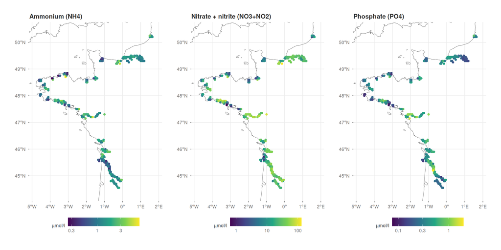

Mean predicted concentration in cells of 0.05° (log colour scale).

```r
nutrient_cell <- nutrient |>
  mutate(longitude = round(longitude / 0.05) * 0.05, latitude = round(latitude / 0.05) * 0.05) |>
  summarise(pred = exp(mean(log_pred)), n = n(), .by = c(nutrient, longitude, latitude))
purrr::map(levels(nutrient_cell$nutrient), \(k) {
  ggplot(filter(nutrient_cell, nutrient == k)) +
    geom_sf(data = coast, color = "grey30", linewidth = 0.2) +
    geom_point(aes(longitude, latitude, color = pred), size = 1.5) +
    coord_sf(xlim = range(visit$longitude) + c(-0.2, 0.2), ylim = range(visit$latitude) + c(-0.2, 0.2)) +
    scale_color_viridis_c(transform = "log10", labels = scales::label_number(drop0trailing = TRUE), name = "µmol/l", guide = guide_colorbar(barwidth = 10)) +
    labs(x = NULL, y = NULL, title = k) +
    theme(axis.line = element_blank(), legend.position = "bottom")
}) |>
  patchwork::wrap_plots(nrow = 1)
```

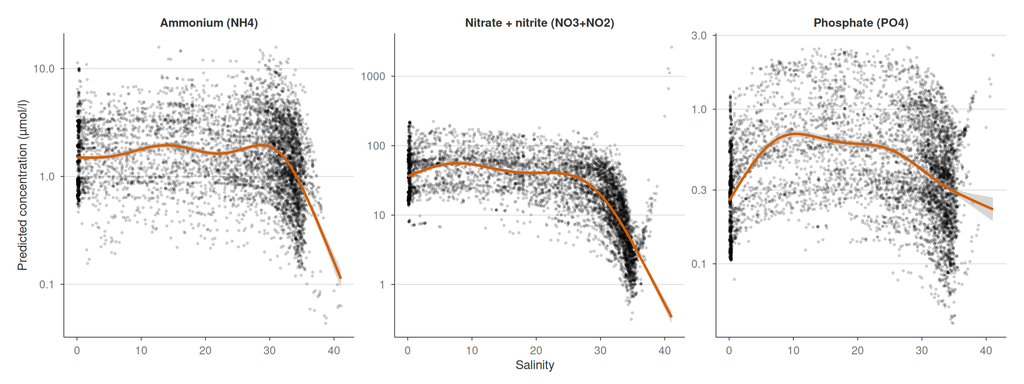

Predicted concentration against measured salinity at the operations (points: operations; line: smooth).

```r
ggplot(nutrient, aes(salinity, pred)) +
  geom_point(alpha = 0.15, size = 0.6) +
  geom_smooth(method = "gam", formula = y ~ s(x, k = 6), color = "#D55E00") +
  facet_wrap(~nutrient, scales = "free_y") +
  scale_y_log10() +
  labs(x = "Salinity", y = "Predicted concentration (µmol/l)")
```

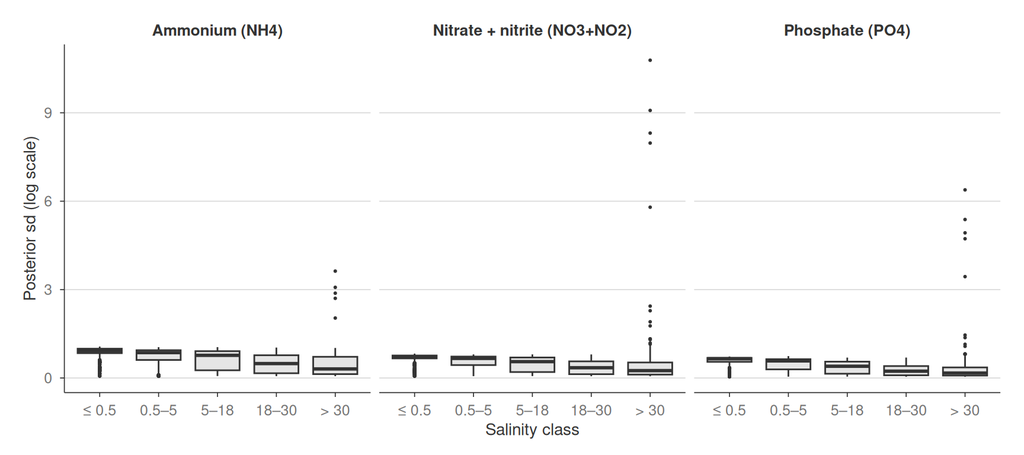

Posterior standard deviation of the predicted log concentration, per salinity class.

```r
nutrient |>
  mutate(class = cut(salinity, c(-Inf, 0.5, 5, 18, 30, Inf), c("≤ 0.5", "0.5–5", "5–18", "18–30", "> 30"))) |>
  ggplot(aes(class, sd)) +
  geom_boxplot(outlier.size = 0.4, fill = "grey90") +
  facet_wrap(~nutrient) +
  labs(x = "Salinity class", y = "Posterior sd (log scale)")
```

**Results:**

- Nitrate is high up to salinity ~30 and falls steeply in marine water (dilution of river water); ammonium and phosphate vary less with salinity and more between places (e.g. high phosphate and ammonium in parts of the Gironde and the Loire).
- The predictions are uncertain in the upper estuaries: the posterior standard deviation of the log concentration is about 0.9 for ammonium in fresh water (a factor of 2.5), against 0.3 at sea: REPHY samples are mostly marine (5.7% of the samples below salinity 5).

## Nutrients and the baseline variables

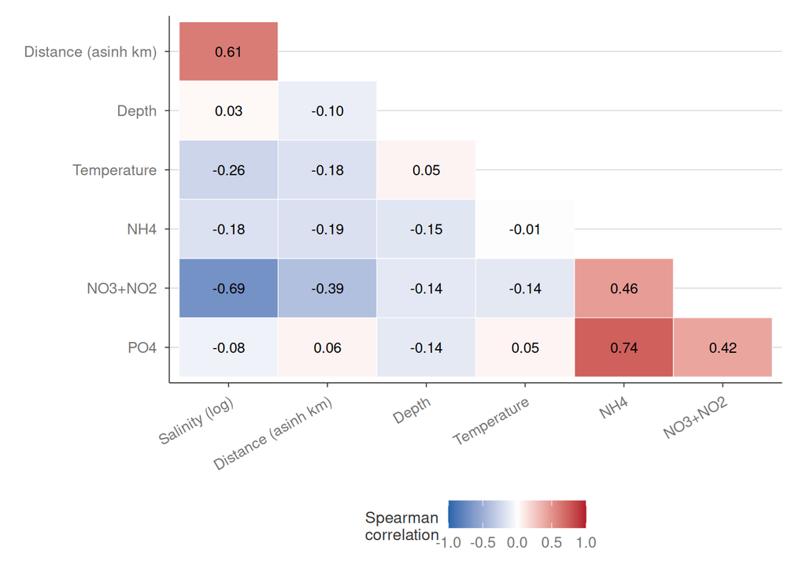

Pairwise Spearman correlations of the baseline continuous variables and the predicted log concentrations at the operations.

```r
wide <- nutrient |>
  select(operation_id, parameter_code, log_pred) |>
  tidyr::pivot_wider(names_from = parameter_code, values_from = log_pred) |>
  inner_join(visit, by = "operation_id")
variable <- wide |>
  transmute(
    `Salinity (log)` = log_salinity, `Distance (asinh km)` = distance, Depth = depth_pomet,
    Temperature = temperature, NH4, `NO3+NO2`, PO4
  )
correlation <- cor(variable, method = "spearman")
as_tibble(correlation, rownames = "x") |>
  tidyr::pivot_longer(-x, names_to = "y", values_to = "rho") |>
  mutate(x = factor(x, colnames(correlation)), y = factor(y, rev(colnames(correlation)))) |>
  filter(as.integer(x) < ncol(correlation) + 1 - as.integer(y)) |>
  ggplot(aes(x, y, fill = rho)) +
  geom_tile(color = "white") +
  geom_text(aes(label = sprintf("%.2f", rho)), size = 3.2) +
  scale_fill_gradient2(low = "#2166AC", high = "#B2182B", limits = c(-1, 1)) +
  labs(x = NULL, y = NULL, fill = "Spearman\ncorrelation") +
  theme(axis.text.x = element_text(angle = 30, hjust = 1), panel.grid = element_blank())
```

What the presence model can use is the nutrient variation not already carried by its other terms. The table splits the variance of each log concentration: the share explained by salinity (natural spline of log salinity), then by the water body (POMET zone, standing for the spatial field), year and month, all of which the baseline already contains.

```r
nutrient_variance <- purrr::map_dfr(names(nutrient_label), \(k) {
  d <- filter(wide, !is.na(.data[[k]]))
  y <- d[[k]]
  r2 <- \(f) summary(lm(f, d))$r.squared
  salinity <- r2(y ~ splines::ns(log_salinity, 3))
  baseline <- r2(y ~ splines::ns(log_salinity, 3) + distance + depth_pomet + temperature)
  all <- r2(y ~ splines::ns(log_salinity, 3) + distance + depth_pomet + temperature + zone_id + factor(year) + factor(month))
  vif <- 1 / (1 - r2(y ~ log_salinity + I(log_salinity^2) + distance + depth_pomet + temperature))
  tibble(
    Nutrient = nutrient_label[[k]], `Salinity` = salinity, `Baseline continuous variables` = baseline,
    `+ water body, year, month` = all, `Left for the model` = 1 - all, VIF = vif
  )
})
knitr::kable(
  nutrient_variance, digits = 2,
  caption = "Share of the variance of the predicted log concentration explained by salinity, by the baseline continuous variables, and with the water body, year and month added (cumulative R²); VIF: variance inflation factor of the nutrient among the baseline continuous variables."
)
```

Share of the variance of the predicted log concentration explained by salinity, by the baseline continuous variables, and with the water body, year and month added (cumulative R²); VIF: variance inflation factor of the nutrient among the baseline continuous variables.

| Nutrient | Salinity | Baseline continuous variables | + water body, year, month | Left for the model | VIF |
| --- | --- | --- | --- | --- | --- |
| Ammonium (NH4) | 0.09 | 0.16 | 0.88 | 0.12 | 1.14 |
| Nitrate + nitrite (NO3+NO2) | 0.57 | 0.67 | 0.90 | 0.10 | 2.16 |
| Phosphate (PO4) | 0.17 | 0.19 | 0.95 | 0.05 | 1.20 |

**Results:**

- Collinearity is not the problem: the variance inflation factors stay below 3. Nitrate is the most tied to salinity (57% of its variance); ammonium and phosphate are correlated with each other (0.74) and little with salinity.
- **Little variation is left for the presence model.** Salinity, the other baseline variables, the water body, the year and the month together explain 88% to 95% of the predicted log concentrations. This comes from the structure of the D7 model: a fixed spatial field, a salinity effect and year and month effects shared by all estuaries, with no change of the spatial pattern between years or seasons. The presence model already contains each of these terms, so a nutrient effect would be estimated from the remaining 5% to 12%, mostly small differences within a water body.

*To discuss:*

- With these predictions, a nutrient effect in the presence model would mostly be confounded with the spatial field (where nutrients are high) and with the year and month effects (when they are high). To get nutrient variation that the baseline does not already carry, the concentrations need to vary between estuaries differently from year to year or season to season. Options:
  - a REPHY model with a space-time interaction (e.g. a spatial field per year, or per season), heavier to fit;
  - the REPHY samples themselves, nearest in space and time to each operation (sparse, but real space-time variation);
  - yearly nutrient inputs of each estuary from the river stations upstream (NAIADES, as in D14), which vary between estuaries and years, and also cover the upper estuaries where REPHY is sparse.
- The predictions are least certain in the upper estuaries, where the flounder is most frequent.

## River inputs per estuary (NAIADES)

Yearly nutrient concentrations of the rivers flowing into each estuary, from the NAIADES river stations (D14; target `estuary_nutrient`, `summarise_estuary_nutrient()`):

1. **Estuaries:** the POMET zones grouped into 29 estuaries, each with its river mouths (tables `pomet_estuary`, `pomet_estuary_mouth`, set by hand).
2. **Station to estuary:** each NAIADES station follows the flow directions (HydroSHEDS, as in D15) down to its sea outlet, which gives its river mouth (`link_station_mouth()`).
3. **Station of each mouth:** the most downstream station (largest drained area) outside the transitional and coastal water bodies (so the river input, not the estuary itself), with at least 10 yearly means in 2005–2019. Yearly means as in D14: at least 4 samples over 3 seasons.
4. **Value of an estuary-year:** the yearly mean (log10 mg/l) of its station, or the mean of its stations weighted by the catchment area of their mouth (years missing at one of its stations dropped).

```r
estuary_nutrient <- tar_read(estuary_nutrient)
estuary_nutrient$station |>
  left_join(sf::st_drop_geometry(tar_read(naiades_station)) |> select(code_station, libelle_station), by = "code_station") |>
  transmute(Estuary = estuary, Station = libelle_station, `Share of the catchment` = share, Years = years) |>
  knitr::kable(digits = 2, caption = "NAIADES station of each river mouth: share of the mouth catchment drained at the station, and number of yearly means in 2005-2019.")
```

NAIADES station of each river mouth: share of the mouth catchment drained at the station, and number of yearly means in 2005-2019.

| Estuary | Station | Share of the catchment | Years |
| --- | --- | --- | --- |
| Gironde | La Garonne à Couthures | 0.63 | 14 |
| Seine | LA SEINE A COURCELLES-SUR-SEINE 3 | 0.85 | 13 |
| Dives | LA DIVES A BIEVILLE-QUETIEVILLE 1 | 0.37 | 15 |
| Baie de Caen (Orne) | L’ORNE A LOUVIGNY 1 | 0.85 | 13 |
| Baie des Veys | LA DOUVE A LIESVILLE-SUR-DOUVE 1 | 0.53 | 15 |
| Baie des Veys | LA VIRE A PONT-HEBERT 3 | 0.52 | 15 |
| Mont-Saint-Michel | COUESNON à SOUGEAL (ANTRAIN) | 0.77 | 15 |
| Mont-Saint-Michel | LA SÉLUNE A SAINT-AUBIN-DE-TERREGATTE 1 | 0.47 | 15 |
| Somme | LA SOMME CANALISÉE À CAMBRON (80) | 0.90 | 13 |
| Pertuis Charentais | La Charente à Taillebourg | 0.76 | 14 |
| Pertuis Charentais | La Seudre à St-André de Lidon | 0.30 | 12 |
| Baie de Morlaix | QUEFFLEUTH À SAINT-MARTIN-DES-CHAMPS | 0.32 | 15 |
| Baie de Morlaix | R PENZE À TAULE | 0.66 | 11 |
| Rance | RANCE à SAINT-ANDRE-DES-EAUX | 0.47 | 15 |
| Trieux | TRIEUX à PLOUEC-DU-TRIEUX | 0.47 | 13 |
| Jaudy | JAUDY à MANTALLOT | 0.39 | 15 |
| Léguer | LEGUER à PLOUBEZRE | 0.80 | 15 |
| Aber Wrac’h | ABER WRAC’H à LANARVILY | 0.59 | 15 |
| Aber Benoit | ABER BENOIT à PLOUVIEN | 0.27 | 11 |
| Élorn | ELORN à PLOUEDERN | 0.66 | 15 |
| Aulne | AULNE à SAINT-SEGAL | 0.78 | 11 |
| Goyen | GOYEN à PONT-CROIX | 0.57 | 15 |
| Pont-l’Abbé | RAU DE PONT L’ABBE à PLONEOUR-LANVERN | 0.30 | 15 |
| Odet | ODET à QUIMPER | 0.29 | 15 |
| Aven-Belon | AVEN à PONT-AVEN | 0.51 | 13 |
| Laïta | ELLE à ARZANO | 0.64 | 15 |
| Blavet-Scorff | BLAVET à LANGUIDIC | 0.77 | 15 |
| Etel | RAU DE LA DEMI VILLE à LANDEVANT | 0.17 | 12 |
| Auray | RAU D’AURAY ou LOC’H à BRECH | 0.49 | 15 |
| Vilaine | VILAINE à RIEUX | 0.96 | 15 |
| Loire | LOIRE à MONTJEAN-SUR-LOIRE | 0.93 | 15 |
| Lay | LAY à LA CLAYE | 0.77 | 15 |
| Sèvre Niortaise | SEVRE NIORTAISE à MARANS | 0.89 | 15 |

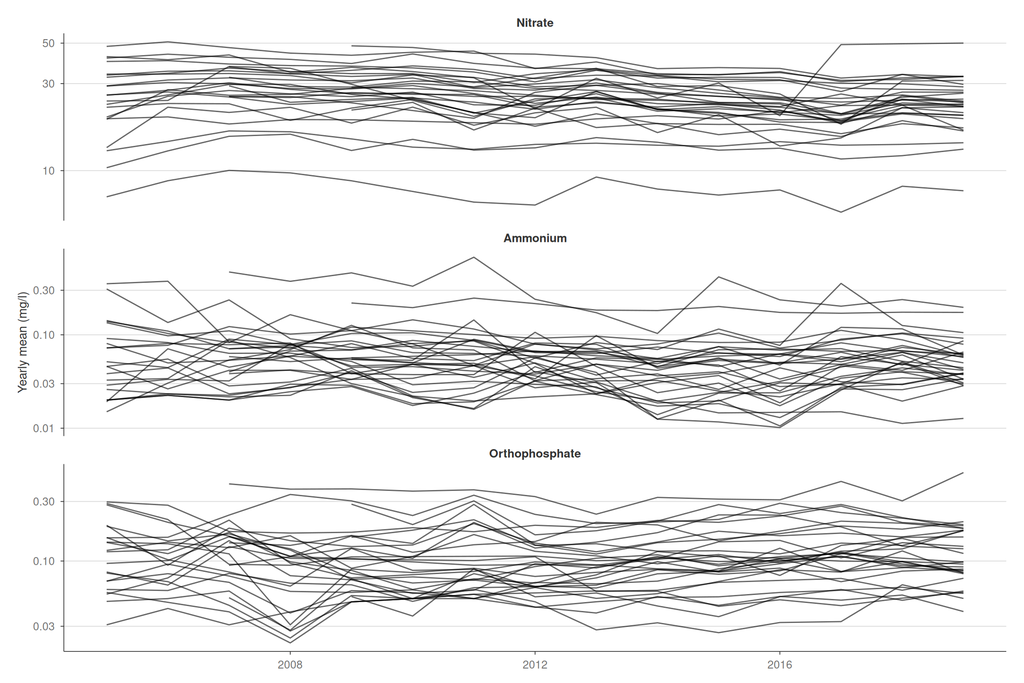

Yearly mean concentration of the river inputs of each estuary (log scale).

```r
river_label <- c(nitrate = "Nitrate", ammonium = "Ammonium", orthophosphate = "Orthophosphate")
estuary_nutrient$estuary_year |>
  tidyr::pivot_longer(names(river_label), names_to = "nutrient", values_to = "log10") |>
  mutate(nutrient = factor(river_label[nutrient], river_label), value = 10^log10) |>
  ggplot(aes(year, value, group = estuary)) +
  geom_line(alpha = 0.6) +
  facet_wrap(~nutrient, scales = "free_y", ncol = 1) +
  scale_y_log10() +
  labs(x = NULL, y = "Yearly mean (mg/l)")
```

```r
river_variance <- purrr::map_dfr(names(river_label), \(k) {
  d <- estuary_nutrient$estuary_year
  r2 <- \(f) summary(lm(f, d))$r.squared
  between <- r2(reformulate("estuary", k))
  shared <- r2(reformulate(c("estuary", "factor(year)"), k))
  tibble(
    Nutrient = river_label[[k]], `Between estuaries` = between, `+ years shared by all estuaries` = shared,
    `Left: estuary-specific years` = 1 - shared,
    `Within-estuary sd (log10)` = sd(stats::resid(stats::lm(reformulate("estuary", k), d)))
  )
})
knitr::kable(river_variance, digits = 2, caption = "Share of the variance of the yearly log10 concentrations (estuary-years) explained by the estuary, then by the year (cumulative R²), and standard deviation within estuaries.")
```

Share of the variance of the yearly log10 concentrations (estuary-years) explained by the estuary, then by the year (cumulative R²), and standard deviation within estuaries.

| Nutrient | Between estuaries | + years shared by all estuaries | Left: estuary-specific years | Within-estuary sd (log10) |
| --- | --- | --- | --- | --- |
| Nitrate | 0.86 | 0.92 | 0.08 | 0.06 |
| Ammonium | 0.73 | 0.77 | 0.23 | 0.16 |
| Orthophosphate | 0.81 | 0.84 | 0.16 | 0.11 |

**Results:**

- Every estuary gets a station; 94.4% of the POMET operations have the river inputs of their estuary and year. Most stations drain more than half of their mouth catchment; a few small Breton rivers only a tributary or the upper part (Etel, Odet, Aber Benoit, Pont-l’Abbé: under a third).
- **The river inputs differ mostly between estuaries.** The estuary explains 86% of the variance of yearly nitrate, 73% of ammonium and 81% of phosphate. What changes from year to year within an estuary, apart from the years shared by all estuaries, is 8% (nitrate) to 23%; for nitrate, the yearly mean of an estuary varies by about 14% (one sd) around its own mean.

*To discuss:*

- As for the estuary descriptors (D19), a nutrient effect estimated from these inputs would mostly rest on the differences between the 29 estuaries, which the spatial field already takes. With the field, the model can only use the estuary-specific years, a small part of the variance (smallest for nitrate). Testing the between-estuary contrast needs a model without field (or with an iid estuary effect) and a leave-one-estuary-out cross-validation.
- The Gironde input is the Garonne only (the station with the largest drained area of the pooled Gironde mouth); the Dordogne (about a third of the catchment) is missing.
- Yearly means of concentration, not loads: the discharge of the year is not used.
- The Dives nitrate doubles from 2017 on (about 20–30 mg/l before, about 50 after, at every sample) and stays there: more likely a change of laboratory or of sampling point than a real change; to check before using the Dives years.

## Next steps

- Fit the presence models with the river inputs on top of the D19 baseline, one nutrient at a time (WAIC), with the field (estuary-specific years only) and without it (between-estuary contrast).